# Machine Learning - Personal Loan Campaign

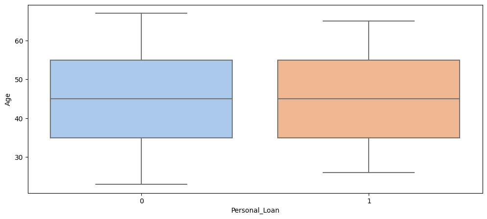

```python
distribution_plot(df,'Personal_Loan','Age')
```

1. It is observed that the mean age for customers accepting and not accepting personal loans is very close to the value 45 years.
2. As expected from the pair plot Age does not have a relation with our target variable, hence a negligible prediction power

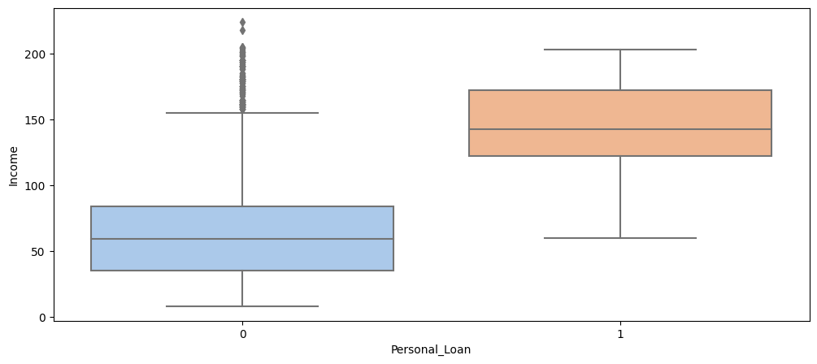

```python
distribution_plot(df,'Personal_Loan','Income')
```

1. As expected, The Income variable varies greatly between customers who accepted and not accepted the personal loan.
2. The mean income for the customers who did not accept the loan is approx USD 65K
3. The mean income for the customers who did accept the loan is approx USD 145K
4. This shows that the income level of the customer has a high impact on the customer decision to accept a personal loan, The higher the income, the more chances the customer will accept a personal loan1.

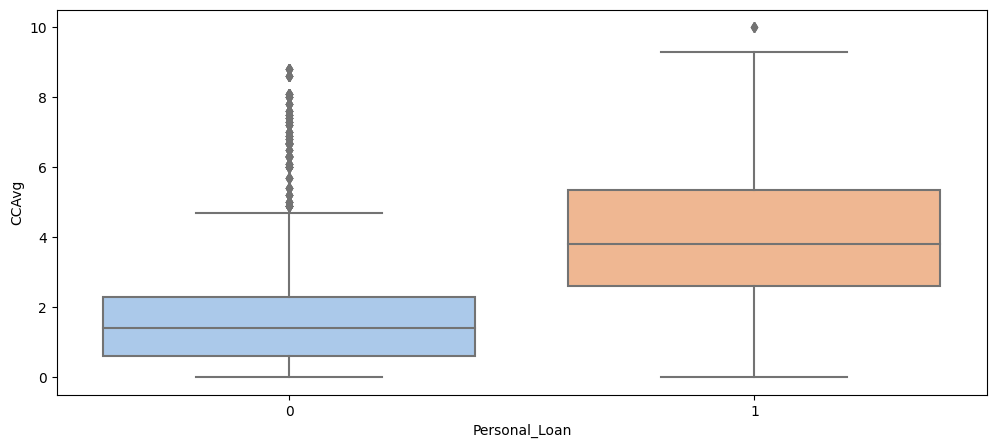

```python
distribution_plot(df,'Personal_Loan','CCAvg')
```

1. It is observed that the mean value of CCAvg of customers not accepting a personal loan is approx USD 1.6 K USDmuch less than the mean value of customers accepting personal loan of approx USD 4K. hence customers who accept personal loan spends more money on monthly basis

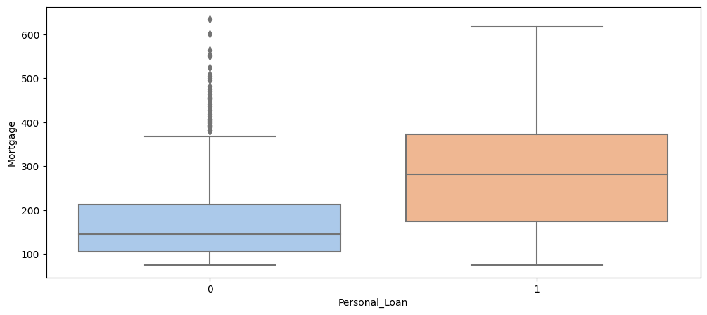

```python
distribution_plot(mort_copy,'Personal_Loan','Mortgage')
```